# Classification

Joseph Rickert

May 13, 2016

This script presents a binary classification problem using a cell segmentation data set that is included in the package. The data is described in the paper: Hill et al “Impact of image segmentation on high-content screening data quality for SK-BR-3 cells” BMC fioinformatics (2007) vol 8 (1) pp. 340

“Well-segmented”" cells are cells for which location and size may be accurrately detremined through optical measurements. Cells that are not Well-segmented (WS) are said to be “Poorly-segmented”" (PS). Given a set of optical measurements can we predict which cells will be PS?

## Setup

Load required packages

```r
library(caret)        # just for confusion matrix
```

```r
library(corrplot)           # plot correlations
library(rattle)       # Plot Tree
library(rpart)              # CART Decision Trees
library(ROCR)         # Plot the ROC Curve
```

Function to divide data into training, and test sets

```r
splitData <- function(data=dF,pctTrain=0.7)
{
  # fcn to create indices to divide data into random
  # training, validation and testing data sets
  N <- nrow(data)
  trainInd <- sample(N, pctTrain*N)
  testInd <- setdiff(seq_len(N),trainInd)
  indexList <- list(trainInd,testInd)
  return(indexList)
}

set.seed(42)                                     # Set seed for simulation repeatability
```

## Read the Data and Prepare the Training and Test Sets

Read the Data

```r
data(segmentationData)      # Load the segmentation data set
head(segmentationData)
```

```
##        Cell  Case Class   AngleCh1 AreaCh1 AvgIntenCh1 AvgIntenCh2
## 1 207827637  Test    PS 143.247705     185    15.71186    4.954802
## 2 207932307 Train    PS 133.752037     819    31.92327  206.878517
## 3 207932463 Train    WS 106.646387     431    28.03883  116.315534
## 4 207932470 Train    PS  69.150325     298    19.45614  102.294737
## 5 207932455  Test    PS   2.887837     285    24.27574  112.415441
## 6 207827656  Test    WS  40.748298     172   325.93333  653.606061
##   AvgIntenCh3 AvgIntenCh4 ConvexHullAreaRatioCh1 ConvexHullPerimRatioCh1
## 1    9.548023    2.214689               1.124509               0.9196827
## 2   69.916880  164.153453               1.263158               0.7970801
## 3   63.941748  106.696602               1.053310               0.9354750
## 4   28.217544   31.028070               1.202625               0.8658291
## 5   20.474265   40.577206               1.109333               0.9568124
## 6  128.690909  346.854545               1.005831               0.9926363
##   DiffIntenDensityCh1 DiffIntenDensityCh3 DiffIntenDensityCh4
```

[output cut: 90 more lines]

```r
dF <- segmentationData[,-c(1,2)]  #Remove non-predictive variables
head(dF,2)
```

```
##   Class AngleCh1 AreaCh1 AvgIntenCh1 AvgIntenCh2 AvgIntenCh3 AvgIntenCh4
## 1    PS 143.2477     185    15.71186    4.954802    9.548023    2.214689
## 2    PS 133.7520     819    31.92327  206.878517   69.916880  164.153453
##   ConvexHullAreaRatioCh1 ConvexHullPerimRatioCh1 DiffIntenDensityCh1
## 1               1.124509               0.9196827            29.51923
## 2               1.263158               0.7970801            31.87500
##   DiffIntenDensityCh3 DiffIntenDensityCh4 EntropyIntenCh1 EntropyIntenCh3
## 1            13.77564            6.826923        4.969781        4.371017
## 2            43.12228           79.308424        6.087592        6.642761
##   EntropyIntenCh4 EqCircDiamCh1 EqEllipseLWRCh1 EqEllipseOblateVolCh1
## 1        2.718884      15.36954        3.060676              336.9691
## 2        7.880155      32.30558        1.558394             2232.9055
##   EqEllipseProlateVolCh1 EqSphereAreaCh1 EqSphereVolCh1 FiberAlign2Ch3
## 1               110.0963        742.1156       1900.996       1.000000
## 2              1432.8246       3278.7256      17653.525       1.487935
##   FiberAlign2Ch4 FiberLengthCh1 FiberWidthCh1 IntenCoocASMCh3
## 1       1.000000       26.98132      7.410365      0.01118390
## 2       1.352374       64.28230     13.167079      0.02805106
##   IntenCoocASMCh4 IntenCoocContrastCh3 IntenCoocContrastCh4
## 1      0.05044801            40.751777            13.895439
## 2      0.01259498             8.227953             6.984046
##   IntenCoocEntropyCh3 IntenCoocEntropyCh4 IntenCoocMaxCh3 IntenCoocMaxCh4
## 1            7.199458            5.249744      0.07741935      0.17197452
## 2            6.822138            7.098988      0.15321477      0.07387141
##   KurtIntenCh1 KurtIntenCh3 KurtIntenCh4 LengthCh1 NeighborAvgDistCh1
## 1   -0.6567441   -0.6080583    0.7258145  26.20779           370.4543
## 2   -0.2487691   -0.3307839   -0.2652638  47.21855           174.4442
##   NeighborMinDistCh1 NeighborVarDistCh1  PerimCh1 ShapeBFRCh1 ShapeLWRCh1
## 1           99.10349          127.96080  68.78338   0.6651480    2.462450
## 2           30.11114           81.38063 154.89876   0.5397584    1.468181
##   ShapeP2ACh1 SkewIntenCh1 SkewIntenCh3 SkewIntenCh4 SpotFiberCountCh3
## 1    1.883006    0.4545048    0.4603934    1.2327736                 1
## 2    2.255810    0.3987047    0.6197308    0.5272631                 4
##   SpotFiberCountCh4 TotalIntenCh1 TotalIntenCh2 TotalIntenCh3
## 1                 5          2781           701          1690
## 2                12         24964        160998         54675
##   TotalIntenCh4 VarIntenCh1 VarIntenCh3 VarIntenCh4 WidthCh1 XCentroid
## 1           392    12.47468    7.609035      2.7141 10.64297        42
## 2        128368    18.80923   56.715352    118.3881 32.16126       215
##   YCentroid
## 1        14
## 2       347
```

```r
rm(segmentationData)     # Free up some memory space

indices <- splitData(dF)       # Generate indidices to split data
trainInd <- unlist(indices[1]) # Training data
testInd <- unlist(indices[2])  # Test data

dim(dF[trainInd,])
```

```
## [1] 1413   59
```

```r
dim(dF[testInd,])
```

```
## [1] 606  59
```

## Explore the data

Look at summaries of the variables

```r
sapply(dF,summary)
```

```
## $Class
##   PS   WS
## 1300  719
##
## $AngleCh1
##      Min.   1st Qu.    Median      Mean   3rd Qu.      Max.
##   0.03088  53.89000  90.59000  90.49000 126.70000 179.90000
##
## $AreaCh1
##    Min. 1st Qu.  Median    Mean 3rd Qu.    Max.
##   150.0   193.0   253.0   320.3   362.5  2186.0
##
## $AvgIntenCh1
##    Min. 1st Qu.  Median    Mean 3rd Qu.    Max.
##   15.16   35.36   62.34  126.10  143.20 1419.00
##
## $AvgIntenCh2
##    Min. 1st Qu.  Median    Mean 3rd Qu.    Max.
##     1.0    45.0   173.5   189.1   279.3   989.5
##
## $AvgIntenCh3
##    Min. 1st Qu.  Median    Mean 3rd Qu.    Max.
##    0.12   33.50   67.43   96.42  127.30 1206.00
##
## $AvgIntenCh4
##     Min.  1st Qu.   Median     Mean  3rd Qu.     Max.
##   0.5633  40.6800  90.2500 140.7000 191.2000 886.8000
##
## $ConvexHullAreaRatioCh1
##    Min. 1st Qu.  Median    Mean 3rd Qu.    Max.
##   1.006   1.065   1.149   1.206   1.281   2.900
##
## $ConvexHullPerimRatioCh1
##    Min. 1st Qu.  Median    Mean 3rd Qu.    Max.
##  0.5106  0.8570  0.9133  0.8958  0.9556  0.9965
##
## $DiffIntenDensityCh1
##    Min. 1st Qu.  Median    Mean 3rd Qu.    Max.
##   25.76   43.53   55.81   72.66   79.91  442.80
##
```

[output cut: 180 more lines]

```
## $VarIntenCh4
##    Min. 1st Qu.  Median    Mean 3rd Qu.    Max.
##   2.302  47.430  87.250 120.000 159.100 933.500
##
## $WidthCh1
##    Min. 1st Qu.  Median    Mean 3rd Qu.    Max.
##   6.393  13.820  16.190  17.620  19.780  54.740
##
## $XCentroid
##    Min. 1st Qu.  Median    Mean 3rd Qu.    Max.
##     9.0   142.0   262.0   260.7   382.0   501.0
##
## $YCentroid
##    Min. 1st Qu.  Median    Mean 3rd Qu.    Max.
##     8.0    88.0   165.0   177.3   253.0   501.0
```

```r
sapply(dF,class)
```

```
##                   Class                AngleCh1                 AreaCh1
##                "factor"               "numeric"               "integer"
##             AvgIntenCh1             AvgIntenCh2             AvgIntenCh3
##               "numeric"               "numeric"               "numeric"
##             AvgIntenCh4  ConvexHullAreaRatioCh1 ConvexHullPerimRatioCh1
##               "numeric"               "numeric"               "numeric"
##     DiffIntenDensityCh1     DiffIntenDensityCh3     DiffIntenDensityCh4
##               "numeric"               "numeric"               "numeric"
##         EntropyIntenCh1         EntropyIntenCh3         EntropyIntenCh4
##               "numeric"               "numeric"               "numeric"
##           EqCircDiamCh1         EqEllipseLWRCh1   EqEllipseOblateVolCh1
##               "numeric"               "numeric"               "numeric"
##  EqEllipseProlateVolCh1         EqSphereAreaCh1          EqSphereVolCh1
##               "numeric"               "numeric"               "numeric"
##          FiberAlign2Ch3          FiberAlign2Ch4          FiberLengthCh1
##               "numeric"               "numeric"               "numeric"
##           FiberWidthCh1         IntenCoocASMCh3         IntenCoocASMCh4
##               "numeric"               "numeric"               "numeric"
##    IntenCoocContrastCh3    IntenCoocContrastCh4     IntenCoocEntropyCh3
##               "numeric"               "numeric"               "numeric"
##     IntenCoocEntropyCh4         IntenCoocMaxCh3         IntenCoocMaxCh4
##               "numeric"               "numeric"               "numeric"
##            KurtIntenCh1            KurtIntenCh3            KurtIntenCh4
##               "numeric"               "numeric"               "numeric"
##               LengthCh1      NeighborAvgDistCh1      NeighborMinDistCh1
##               "numeric"               "numeric"               "numeric"
##      NeighborVarDistCh1                PerimCh1             ShapeBFRCh1
##               "numeric"               "numeric"               "numeric"
##             ShapeLWRCh1             ShapeP2ACh1            SkewIntenCh1
##               "numeric"               "numeric"               "numeric"
##            SkewIntenCh3            SkewIntenCh4       SpotFiberCountCh3
##               "numeric"               "numeric"               "integer"
##       SpotFiberCountCh4           TotalIntenCh1           TotalIntenCh2
##               "numeric"               "integer"               "numeric"
##           TotalIntenCh3           TotalIntenCh4             VarIntenCh1
##               "integer"               "integer"               "numeric"
##             VarIntenCh3             VarIntenCh4                WidthCh1
##               "numeric"               "numeric"               "numeric"
##               XCentroid               YCentroid
##               "integer"               "integer"
```

Look at the correlations for the independent variables

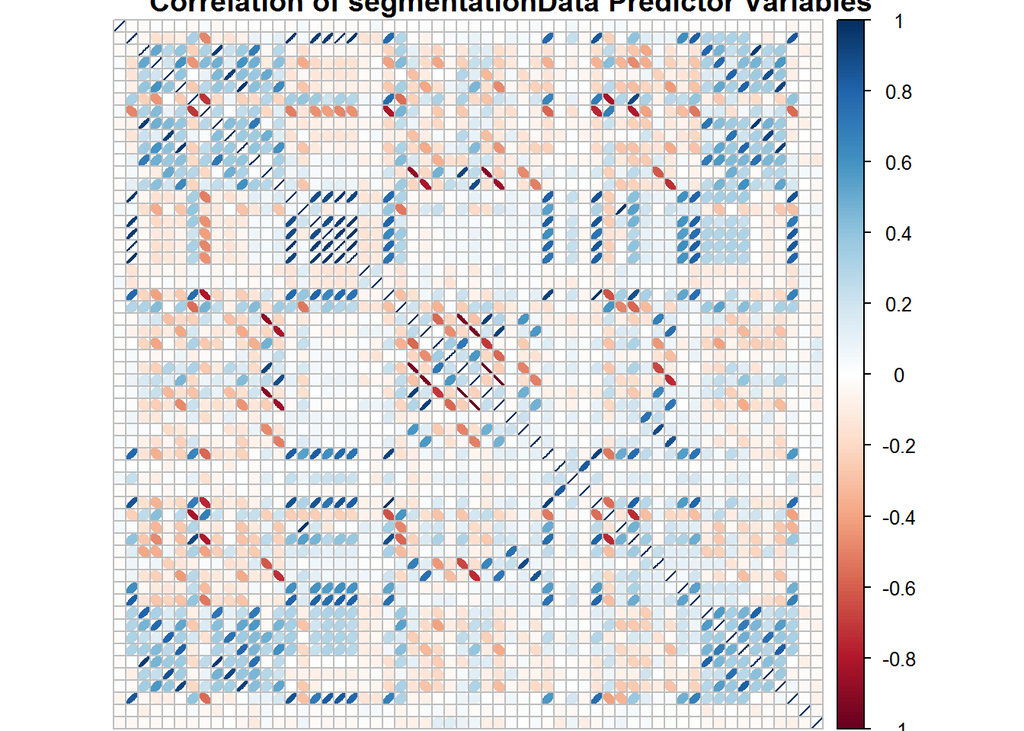

```r
corrplot(cor(dF[,-1]),
         method="ellipse",
         tl.pos="n",
         title="Correlation of segmentationData Predictor Variables")
```

## Build a Tree Model with rpart

The rpart algorithm based on recursive partitioning  
(See section 11.2 of Data Mining with Rattle and R by williams)  
The rpart Algorithm:  
1. - Partition the data set according to some criterion of “best” partition  
2. - Do the same for each of the two new subsets  
3. - Once a partition is made, stick with it (greedy approach)

Measures of “best” partition:  
1. - information gain (the default)  
2. - Gini

Information Gain Algorithm:  
For all possible splits (partitions)  
1. - Split data, D, into to subsets S1 and S2 where D = S1 U S2  
2. - Calculate information I1 and I2 associated with S1 and S2  
3. - Compute total information of split: Info(D,S1,S2) = (|D1|/D)*I1 + (|D2|/|D|)*I2  
4. - Compute the information gain of the split: info(D) - info(D,S1,S2)  
5. - Select split with greatest information gain

Set up the control function for the tree

```r
ctrl <- rpart.control(minsplit = 20,      # Min obs at node for splitting
                      cp = 0.05,          # Complexity parameter
                      maxcompete = 4,     # Num. competor splits in retained
                      maxsurrogate = 5,   # Num. surrogate splits retained
                      usesurrogate = 2,   # How to use surrogate splits
                      xval = 10,          # Num. of cross validations
                      surrogatestyle = 0, # How to select surrogates
                      maxdepth = 30       # Max depth of tree
)
```

Fit the tree

```r
form <- formula(Class~ .)               # Describe the model to R
tree_fit <- rpart(formula=form,
              data=dF[trainInd,],
              control = ctrl)   # Build the model
tree_fit
```

```
## n= 1413
##
## node), split, n, loss, yval, (yprob)
##       * denotes terminal node
##
## 1) root 1413 512 PS (0.63765039 0.36234961)
##   2) TotalIntenCh2< 47256.5 671  59 PS (0.91207154 0.08792846) *
##   3) TotalIntenCh2>=47256.5 742 289 WS (0.38948787 0.61051213)
##     6) FiberWidthCh1< 10.86394 286 106 PS (0.62937063 0.37062937) *
##     7) FiberWidthCh1>=10.86394 456 109 WS (0.23903509 0.76096491) *
```

Interpreting the Model Results

Every line of the output the follows will have  
1. node: a node number  
2. split: the logic for how the node splits the data  
3. n: the number of observations considered at that split  
4. loss: the number of incorrectly classified observations  
5. the majority class at that node  
6. yprob: the distribution of classes at that node

## Examine the results

```r
summary(tree_fit)             # Summary of rpart tree model
```

```
## Call:
## rpart(formula = form, data = dF[trainInd, ], control = ctrl)
##   n= 1413
##
##          CP nsplit rel error    xerror       xstd
## 1 0.3203125      0 1.0000000 1.0000000 0.03529038
## 2 0.1445312      1 0.6796875 0.7246094 0.03230575
## 3 0.0500000      2 0.5351562 0.5664062 0.02965158
##
## Variable importance
##           TotalIntenCh2           FiberWidthCh1             AvgIntenCh2
##                      22                      18                      14
##           TotalIntenCh4           TotalIntenCh1             VarIntenCh4
##                      11                      10                      10
##             ShapeP2ACh1  ConvexHullAreaRatioCh1             ShapeBFRCh1
##                       4                       3                       3
## ConvexHullPerimRatioCh1         EqEllipseLWRCh1
##                       2                       2
##
## Node number 1: 1413 observations,    complexity param=0.3203125
##   predicted class=PS  expected loss=0.3623496  P(node) =1
##     class counts:   901   512
##    probabilities: 0.638 0.362
##   left son=2 (671 obs) right son=3 (742 obs)
##   Primary splits:
##       TotalIntenCh2          < 47256.5   to the left,  improve=192.4535, (0 missing)
##       FiberWidthCh1          < 10.87631  to the left,  improve=175.9694, (0 missing)
##       ShapeP2ACh1            < 1.411005  to the right, improve=141.0387, (0 missing)
##       AvgIntenCh2            < 115.4376  to the left,  improve=132.8083, (0 missing)
##       ConvexHullAreaRatioCh1 < 1.102761  to the right, improve=132.0725, (0 missing)
##   Surrogate splits:
##       AvgIntenCh2   < 142.4849  to the left,  agree=0.836, adj=0.654, (0 split)
##       FiberWidthCh1 < 9.42652   to the left,  agree=0.775, adj=0.526, (0 split)
##       TotalIntenCh4 < 21650.5   to the left,  agree=0.763, adj=0.501, (0 split)
##       TotalIntenCh1 < 16906.5   to the left,  agree=0.749, adj=0.472, (0 split)
##       VarIntenCh4   < 74.03126  to the left,  agree=0.729, adj=0.429, (0 split)
##
## Node number 2: 671 observations
##   predicted class=PS  expected loss=0.08792846  P(node) =0.4748762
##     class counts:   612    59
```

[output cut: 14 more lines]

```
##       ShapeP2ACh1             < 1.646731  to the right, agree=0.834, adj=0.570, (0 split)
##       ConvexHullAreaRatioCh1  < 1.148499  to the right, agree=0.810, adj=0.507, (0 split)
##       ShapeBFRCh1             < 0.5903657 to the left,  agree=0.796, adj=0.472, (0 split)
##       ConvexHullPerimRatioCh1 < 0.9137396 to the left,  agree=0.771, adj=0.406, (0 split)
##       EqEllipseLWRCh1         < 1.808761  to the right, agree=0.768, adj=0.399, (0 split)
##
## Node number 6: 286 observations
##   predicted class=PS  expected loss=0.3706294  P(node) =0.2024062
##     class counts:   180   106
##    probabilities: 0.629 0.371
##
## Node number 7: 456 observations
##   predicted class=WS  expected loss=0.2390351  P(node) =0.3227176
##     class counts:   109   347
##    probabilities: 0.239 0.761
```

Plot the Tree

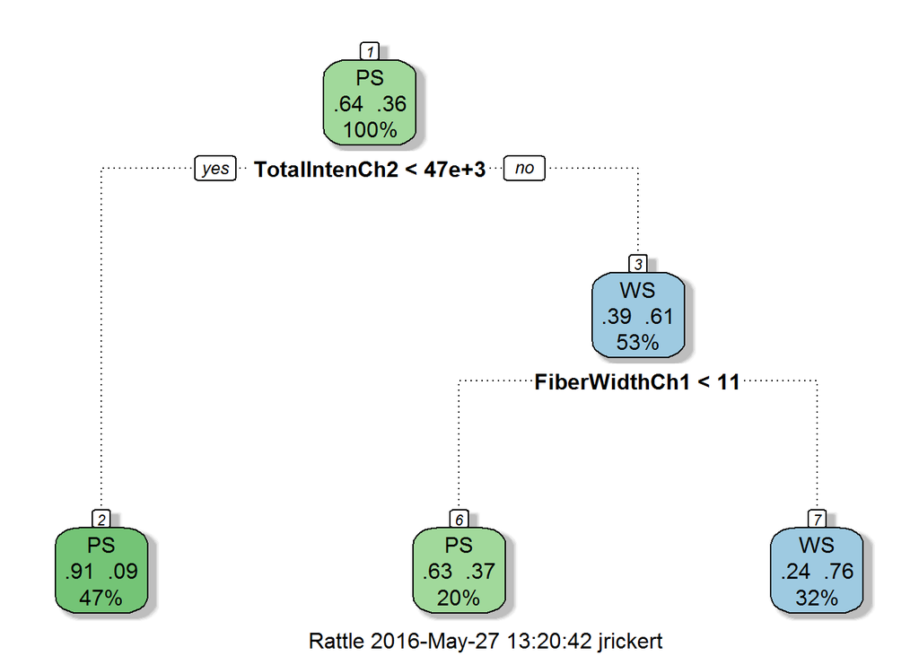

```r
fancyRpartPlot(tree_fit)
```

## Evaluate model performance on the test set

Run the tree model on the test set

```r
pr <- predict(tree_fit, dF[testInd, ], type="class")
```

Calculate the Confusion Matrix

```r
response <- dF[testInd,1] # Actual responses
confusionMatrix(data=pr,reference=response)
```

```
## Confusion Matrix and Statistics
##
##           Reference
## Prediction  PS  WS
##         PS 333  76
##         WS  66 131
##
##                Accuracy : 0.7657
##                  95% CI : (0.7299, 0.7989)
##     No Information Rate : 0.6584
##     P-Value [Acc > NIR] : 6.174e-09
##
##                   Kappa : 0.4729
##  Mcnemar's Test P-Value : 0.4501
##
##             Sensitivity : 0.8346
##             Specificity : 0.6329
##          Pos Pred Value : 0.8142
##          Neg Pred Value : 0.6650
##              Prevalence : 0.6584
##          Detection Rate : 0.5495
##    Detection Prevalence : 0.6749
##       Balanced Accuracy : 0.7337
##
##        'Positive' Class : PS
##
```

Draw the ROC Curve

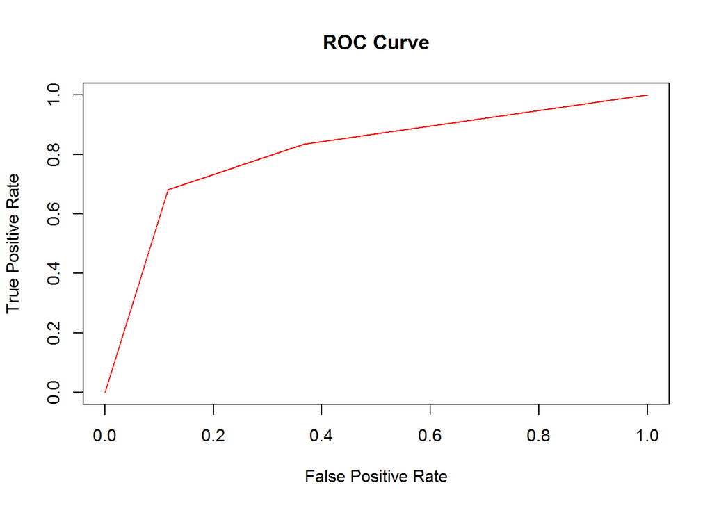

```r
prob <- predict(tree_fit, dF[testInd, ], type="prob")

pred <- prediction(prob[,1],response,label.ordering=c("WS","PS"))
perf <- performance(pred, measure = "tpr", x.measure = "fpr")
plot(perf, col=rainbow(10),
     xlim = c(0,1),
     ylim = c(0,1),
     xlab="False Positive Rate",
     ylab="True Positive Rate",
     main="ROC Curve")
```

### Explore an unpruned tree

The complexity parameter sets the minimum benefit that must be gained at each split of the decision tree. (default = .01) Typical behavior with cp=0 is to see the error reate decrease at first and then begin to increase.

```r
ctrl2 <- rpart.control(minsplit = 0,  # Min obs at node for splitting
                       cp = 0,     # Complexity parameter
                       maxcompete = 4, # No. competor splits in retained
                       maxsurrogate = 5, # No. surrogate splits retained
                       usesurrogate = 2, # How to use surrogate splits
                       xval = 10,        # No. of cross validations
                       surrogatestyle = 0, # How to select surrogates
                       maxdepth = 30       # Max depth of tree
)


big_tree <- rpart(formula=form,control=ctrl2,data=dF[trainInd,])
print(big_tree$cptable)
```

```
##              CP nsplit rel error    xerror       xstd
## 1  0.3203125000      0 1.0000000 1.0000000 0.03529038
## 2  0.1445312500      1 0.6796875 0.7207031 0.03224946
## 3  0.0449218750      2 0.5351562 0.5820312 0.02995053
## 4  0.0117187500      3 0.4902344 0.5429688 0.02918632
## 5  0.0087890625      8 0.4316406 0.5742188 0.02980215
## 6  0.0078125000     17 0.3496094 0.5664062 0.02965158
## 7  0.0058593750     23 0.3027344 0.5722656 0.02976472
## 8  0.0048828125     31 0.2558594 0.5878906 0.03006039
## 9  0.0039062500     33 0.2460938 0.5839844 0.02998729
## 10 0.0032552083     59 0.1445312 0.6015625 0.03031206
## 11 0.0029296875     62 0.1347656 0.6054688 0.03038278
## 12 0.0026041667     66 0.1230469 0.6171875 0.03059186
## 13 0.0024414062     69 0.1152344 0.6191406 0.03062625
## 14 0.0019531250     73 0.1054688 0.6191406 0.03062625
## 15 0.0013020833    111 0.0312500 0.6445312 0.03106205
## 16 0.0009765625    117 0.0234375 0.6484375 0.03112726
## 17 0.0000000000    141 0.0000000 0.6699219 0.03147733
```

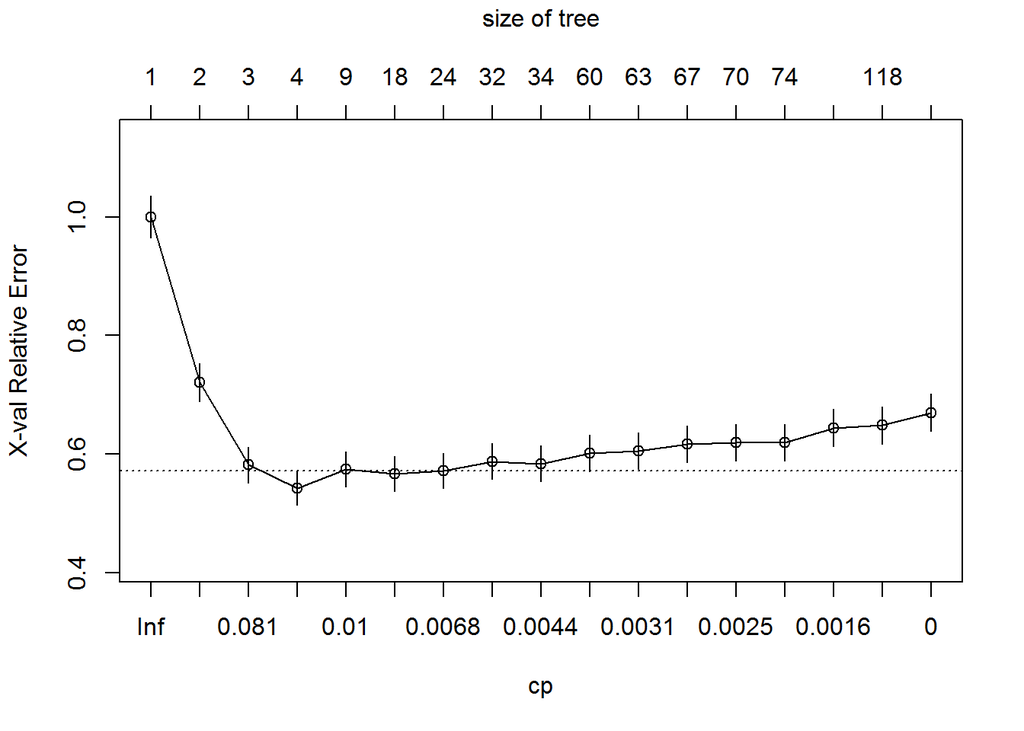

```r
plotcp(big_tree)
```

[figure not shown]

```r
fancyRpartPlot(big_tree)
```